### Liver Diseases have been a widespread issue in many countries. Third World countries suffer from a sparsity of doctors, leading to difficulty in diagnosing patients. With the advent of machine learning technology, we can now try to automate the process of diagnosing patients based on their test results. This saves the doctors and patients a lot of time, and those that are in need of attention can be tended to. This is a simple attempt to solve this calssification problem using different algorithms.

Calling the required libraries:

```r
library(ggplot2)
library(readr)
library(psych)
library(corrplot)
library(ggpubr)
library(caret)
```

Reading the dataset file:

```r
liver_data <- read_csv("indian_liver_patient.csv")
```

Now we explore the dataset to find anomalies and get a better understanding of what course of action to follow:

```r
str(liver_data)
```

```
## Classes 'spec_tbl_df', 'tbl_df', 'tbl' and 'data.frame': 583 obs. of  11 variables:
##  $ Age                       : num  65 62 62 58 72 46 26 29 17 55 ...
##  $ Gender                    : chr  "Female" "Male" "Male" "Male" ...
##  $ Total_Bilirubin           : num  0.7 10.9 7.3 1 3.9 1.8 0.9 0.9 0.9 0.7 ...
##  $ Direct_Bilirubin          : num  0.1 5.5 4.1 0.4 2 0.7 0.2 0.3 0.3 0.2 ...
##  $ Alkaline_Phosphotase      : num  187 699 490 182 195 208 154 202 202 290 ...
##  $ Alamine_Aminotransferase  : num  16 64 60 14 27 19 16 14 22 53 ...
##  $ Aspartate_Aminotransferase: num  18 100 68 20 59 14 12 11 19 58 ...
##  $ Total_Protiens            : num  6.8 7.5 7 6.8 7.3 7.6 7 6.7 7.4 6.8 ...
##  $ Albumin                   : num  3.3 3.2 3.3 3.4 2.4 4.4 3.5 3.6 4.1 3.4 ...
##  $ Albumin_and_Globulin_Ratio: num  0.9 0.74 0.89 1 0.4 1.3 1 1.1 1.2 1 ...
##  $ Dataset                   : num  1 1 1 1 1 1 1 1 2 1 ...
##  - attr(*, "spec")=
##   .. cols(
##   ..   Age = col_double(),
##   ..   Gender = col_character(),
##   ..   Total_Bilirubin = col_double(),
##   ..   Direct_Bilirubin = col_double(),
##   ..   Alkaline_Phosphotase = col_double(),
##   ..   Alamine_Aminotransferase = col_double(),
##   ..   Aspartate_Aminotransferase = col_double(),
##   ..   Total_Protiens = col_double(),
##   ..   Albumin = col_double(),
##   ..   Albumin_and_Globulin_Ratio = col_double(),
##   ..   Dataset = col_double()
##   .. )
```

```r
summary(liver_data)
```

```
##       Age           Gender          Total_Bilirubin  Direct_Bilirubin
##  Min.   : 4.00   Length:583         Min.   : 0.400   Min.   : 0.100
##  1st Qu.:33.00   Class :character   1st Qu.: 0.800   1st Qu.: 0.200
##  Median :45.00   Mode  :character   Median : 1.000   Median : 0.300
##  Mean   :44.75                      Mean   : 3.299   Mean   : 1.486
##  3rd Qu.:58.00                      3rd Qu.: 2.600   3rd Qu.: 1.300
##  Max.   :90.00                      Max.   :75.000   Max.   :19.700
##
##  Alkaline_Phosphotase Alamine_Aminotransferase Aspartate_Aminotransferase
##  Min.   :  63.0       Min.   :  10.00          Min.   :  10.0
##  1st Qu.: 175.5       1st Qu.:  23.00          1st Qu.:  25.0
##  Median : 208.0       Median :  35.00          Median :  42.0
##  Mean   : 290.6       Mean   :  80.71          Mean   : 109.9
##  3rd Qu.: 298.0       3rd Qu.:  60.50          3rd Qu.:  87.0
##  Max.   :2110.0       Max.   :2000.00          Max.   :4929.0
##
##  Total_Protiens     Albumin      Albumin_and_Globulin_Ratio
##  Min.   :2.700   Min.   :0.900   Min.   :0.3000
##  1st Qu.:5.800   1st Qu.:2.600   1st Qu.:0.7000
##  Median :6.600   Median :3.100   Median :0.9300
##  Mean   :6.483   Mean   :3.142   Mean   :0.9471
##  3rd Qu.:7.200   3rd Qu.:3.800   3rd Qu.:1.1000
##  Max.   :9.600   Max.   :5.500   Max.   :2.8000
##                                  NA's   :4
##     Dataset
##  Min.   :1.000
##  1st Qu.:1.000
##  Median :1.000
##  Mean   :1.286
##  3rd Qu.:2.000
##  Max.   :2.000
##
```

From these operations we see that there are 10 attributes (dataset being our target variable), and 583 observations. We also see that there are four null values, which need to be dealt with before model building. Hence eliminating the null values:

```r
liver_data <- liver_data[complete.cases(liver_data), ]
#Change 2 to 0 in target variable
liver_data[liver_data$Dataset==2,]$Dataset<-0
```

Verifying whether all the anamolies are dealt with:

```r
str(liver_data)
```

```
## Classes 'tbl_df', 'tbl' and 'data.frame':    579 obs. of  11 variables:
##  $ Age                       : num  65 62 62 58 72 46 26 29 17 55 ...
##  $ Gender                    : chr  "Female" "Male" "Male" "Male" ...
##  $ Total_Bilirubin           : num  0.7 10.9 7.3 1 3.9 1.8 0.9 0.9 0.9 0.7 ...
##  $ Direct_Bilirubin          : num  0.1 5.5 4.1 0.4 2 0.7 0.2 0.3 0.3 0.2 ...
##  $ Alkaline_Phosphotase      : num  187 699 490 182 195 208 154 202 202 290 ...
##  $ Alamine_Aminotransferase  : num  16 64 60 14 27 19 16 14 22 53 ...
##  $ Aspartate_Aminotransferase: num  18 100 68 20 59 14 12 11 19 58 ...
##  $ Total_Protiens            : num  6.8 7.5 7 6.8 7.3 7.6 7 6.7 7.4 6.8 ...
##  $ Albumin                   : num  3.3 3.2 3.3 3.4 2.4 4.4 3.5 3.6 4.1 3.4 ...
##  $ Albumin_and_Globulin_Ratio: num  0.9 0.74 0.89 1 0.4 1.3 1 1.1 1.2 1 ...
##  $ Dataset                   : num  1 1 1 1 1 1 1 1 0 1 ...
```

```r
summary(liver_data)
```

```
##       Age           Gender          Total_Bilirubin  Direct_Bilirubin
##  Min.   : 4.00   Length:579         Min.   : 0.400   Min.   : 0.100
##  1st Qu.:33.00   Class :character   1st Qu.: 0.800   1st Qu.: 0.200
##  Median :45.00   Mode  :character   Median : 1.000   Median : 0.300
##  Mean   :44.78                      Mean   : 3.315   Mean   : 1.494
##  3rd Qu.:58.00                      3rd Qu.: 2.600   3rd Qu.: 1.300
##  Max.   :90.00                      Max.   :75.000   Max.   :19.700
##  Alkaline_Phosphotase Alamine_Aminotransferase Aspartate_Aminotransferase
##  Min.   :  63.0       Min.   :  10.00          Min.   :  10.0
##  1st Qu.: 175.5       1st Qu.:  23.00          1st Qu.:  25.0
##  Median : 208.0       Median :  35.00          Median :  42.0
##  Mean   : 291.4       Mean   :  81.13          Mean   : 110.4
##  3rd Qu.: 298.0       3rd Qu.:  61.00          3rd Qu.:  87.0
##  Max.   :2110.0       Max.   :2000.00          Max.   :4929.0
##  Total_Protiens     Albumin      Albumin_and_Globulin_Ratio
##  Min.   :2.700   Min.   :0.900   Min.   :0.3000
##  1st Qu.:5.800   1st Qu.:2.600   1st Qu.:0.7000
##  Median :6.600   Median :3.100   Median :0.9300
##  Mean   :6.482   Mean   :3.139   Mean   :0.9471
##  3rd Qu.:7.200   3rd Qu.:3.800   3rd Qu.:1.1000
##  Max.   :9.600   Max.   :5.500   Max.   :2.8000
##     Dataset
##  Min.   :0.000
##  1st Qu.:0.000
##  Median :1.000
##  Mean   :0.715
##  3rd Qu.:1.000
##  Max.   :1.000
```

The data is now ready. Exploring further to better understand the dataset.

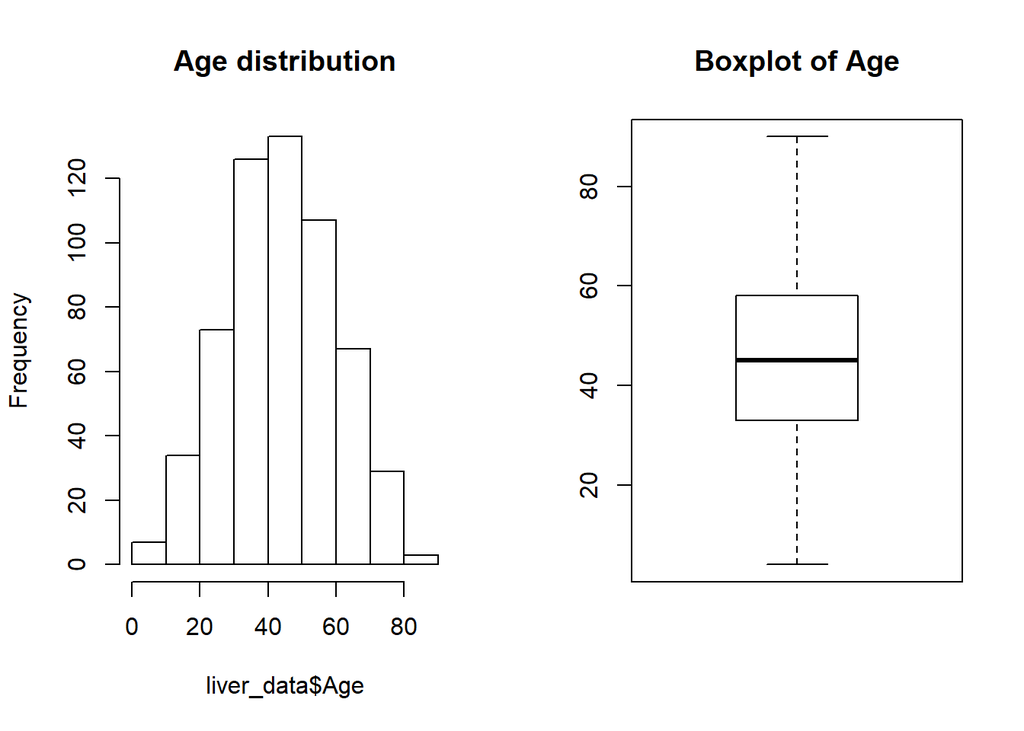

```r
#Age
par(mfrow=c(1,2))
hist(liver_data$Age, main = 'Age distribution')
boxplot(liver_data$Age, main="Boxplot of Age")
```

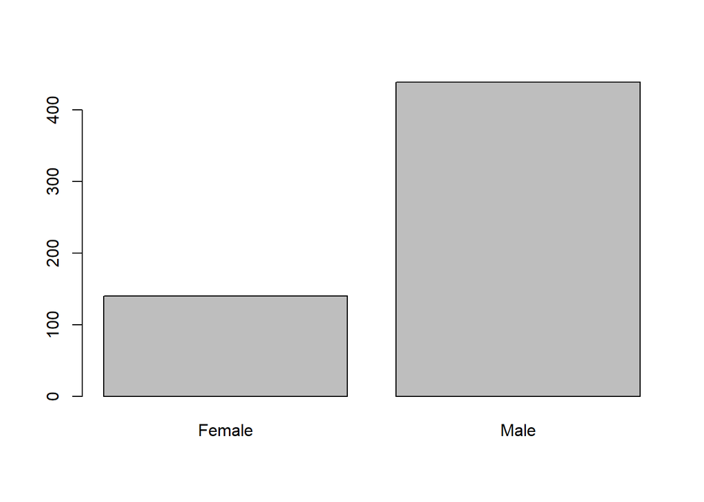

```r
#Gender
par(mfrow=c(1,1))
barplot(table(liver_data$Gender))
```

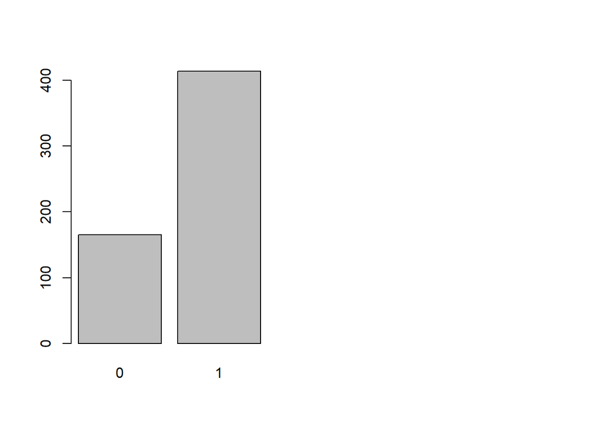

```r
#Dataset(target variable)
par(mfrow=c(1,2))
barplot(table(liver_data$Dataset))
par(mfrow=c(1,1))
```

```r
#Evaluating the number of healthy and unhealthy patients in the dataset(1=unhealthey, 0=healthy)
table(liver_data$Dataset)
```

```
##
##   0   1
## 165 414
```

Evaluating the correlations between the features

```r
# Non-numeric fields are not considered
cor_matrix <- cor(liver_data[,-c(2,11)])
cor_matrix
```

```
##                                     Age Total_Bilirubin Direct_Bilirubin
## Age                         1.000000000     0.011000374     6.784303e-03
## Total_Bilirubin             0.011000374     1.000000000     8.744810e-01
## Direct_Bilirubin            0.006784303     0.874480969     1.000000e+00
## Alkaline_Phosphotase        0.078878350     0.205739173     2.340076e-01
## Alamine_Aminotransferase   -0.087799162     0.213375493     2.331801e-01
## Aspartate_Aminotransferase -0.020498946     0.237323055     2.570224e-01
## Total_Protiens             -0.186248122    -0.007905923     3.270877e-05
## Albumin                    -0.264210935    -0.222086570    -2.284092e-01
## Albumin_and_Globulin_Ratio -0.216408346    -0.206267186    -2.001247e-01
##                            Alkaline_Phosphotase Alamine_Aminotransferase
## Age                                  0.07887835              -0.08779916
## Total_Bilirubin                      0.20573917               0.21337549
## Direct_Bilirubin                     0.23400757               0.23318008
## Alkaline_Phosphotase                 1.00000000               0.12477671
## Alamine_Aminotransferase             0.12477671               1.00000000
## Aspartate_Aminotransferase           0.16657999               0.79186215
## Total_Protiens                      -0.02706202              -0.04243210
## Albumin                             -0.16341865              -0.02865750
## Albumin_and_Globulin_Ratio          -0.23416650              -0.00237499
##                            Aspartate_Aminotransferase Total_Protiens
## Age                                       -0.02049895  -1.862481e-01
## Total_Bilirubin                            0.23732305  -7.905923e-03
## Direct_Bilirubin                           0.25702239   3.270877e-05
## Alkaline_Phosphotase                       0.16657999  -2.706202e-02
## Alamine_Aminotransferase                   0.79186215  -4.243210e-02
## Aspartate_Aminotransferase                 1.00000000  -2.575101e-02
## Total_Protiens                            -0.02575101   1.000000e+00
## Albumin                                   -0.08491457   7.831122e-01
## Albumin_and_Globulin_Ratio                -0.07003983   2.348872e-01
##                                Albumin Albumin_and_Globulin_Ratio
## Age                        -0.26421094                -0.21640835
## Total_Bilirubin            -0.22208657                -0.20626719
## Direct_Bilirubin           -0.22840915                -0.20012469
## Alkaline_Phosphotase       -0.16341865                -0.23416650
## Alamine_Aminotransferase   -0.02865750                -0.00237499
## Aspartate_Aminotransferase -0.08491457                -0.07003983
## Total_Protiens              0.78311217                 0.23488718
## Albumin                     1.00000000                 0.68963234
## Albumin_and_Globulin_Ratio  0.68963234                 1.00000000
```

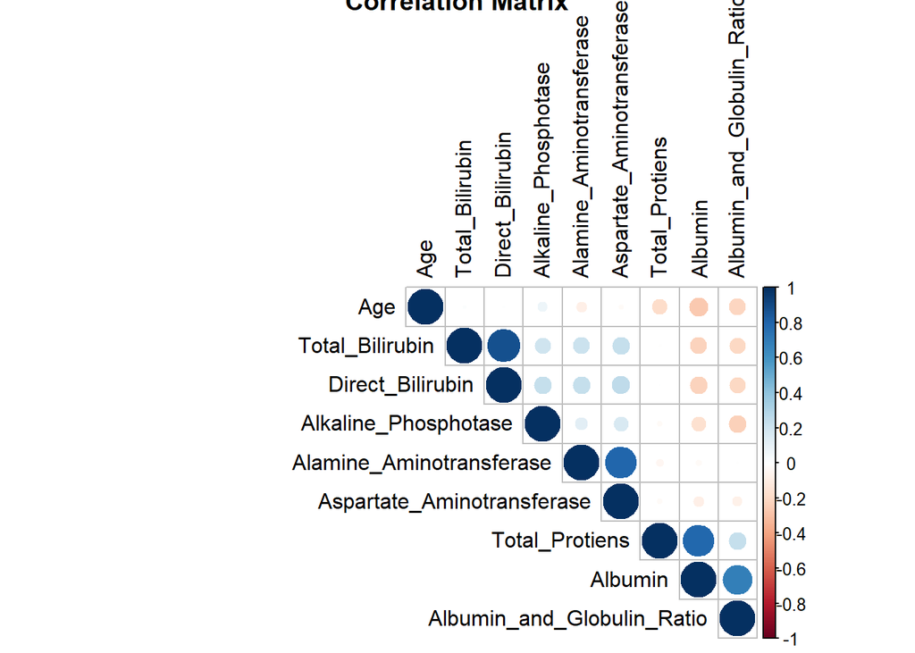

```r
corrplot(cor_matrix,title = "Correlation Matrix",tl.col = "black",type = "upper")
```

Positive correlations are displayed in blue and negative correlations in red color. Color intensity and the size of the circle are proportional to the correlation coefficients.On the right side of the correlogram, the legend color shows the correlation coefficients and the corresponding colors. From the plot it is eveident that there is a high correlation between the following pair : Total_Bilrubin, Direct Bilrubin; Alamine_Amniotransferase, Aspartate_Amniotranferase; Total_Proteins, Albumin. Exploring these correlations further.

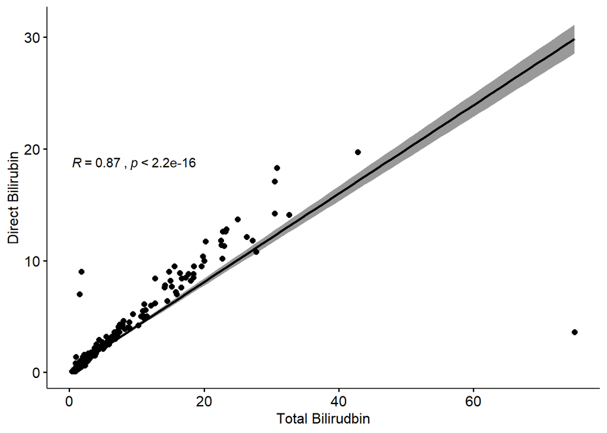

```r
par(mfrow=c(2,2))
ggscatter(data = liver_data, x = "Total_Bilirubin", y = "Direct_Bilirubin",
          add = "reg.line", conf.int = TRUE,
          cor.coef = TRUE, cor.method = "pearson",
          xlab = "Total Bilirudbin", ylab = "Direct Bilirubin")
```

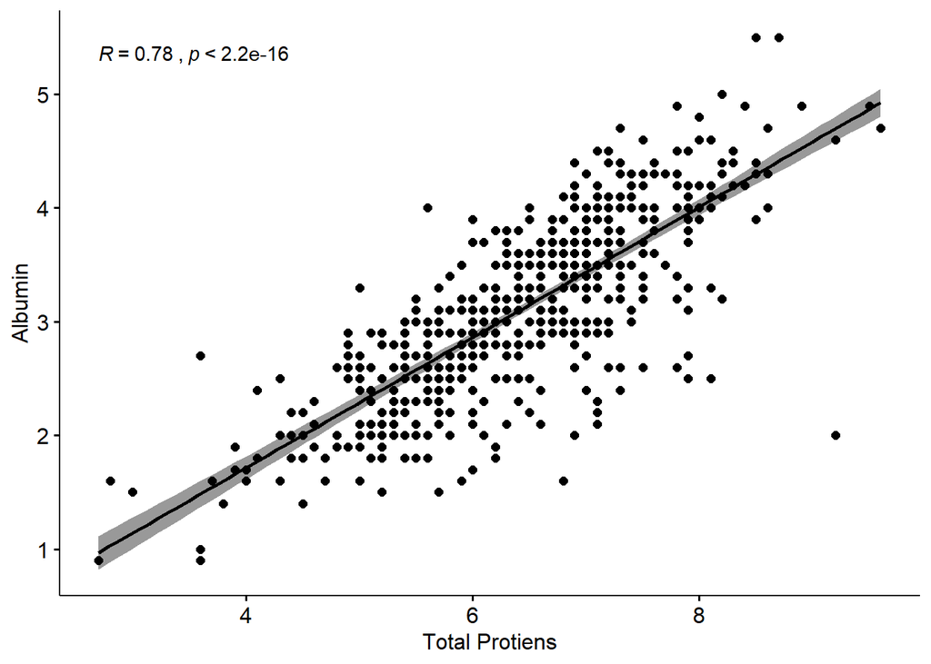

```r
ggscatter(data = liver_data, x = "Total_Protiens", y = "Albumin",
          add = "reg.line", conf.int = TRUE,
          cor.coef = TRUE, cor.method = "pearson",
          xlab = "Total Protiens", ylab = "Albumin")
```

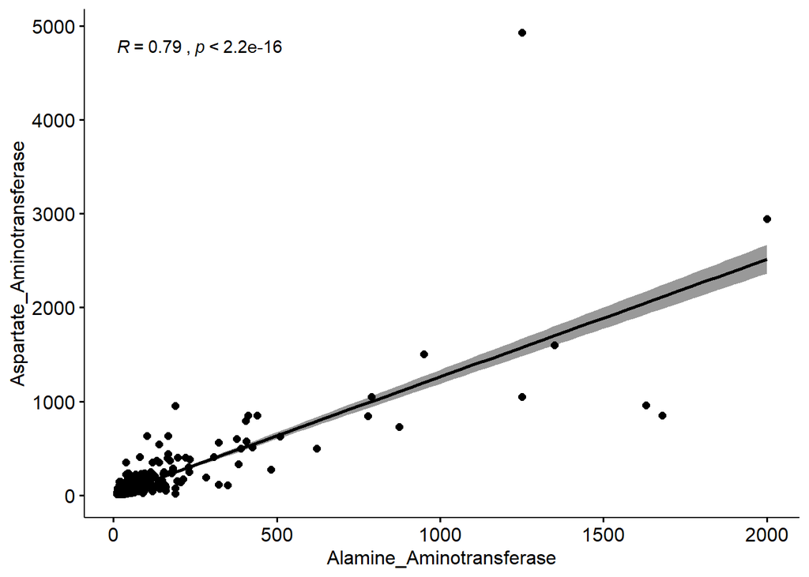

```r
ggscatter(data = liver_data, x = "Alamine_Aminotransferase", y = "Aspartate_Aminotransferase",
          add = "reg.line", conf.int = TRUE,
          cor.coef = TRUE, cor.method = "pearson",
          xlab = "Alamine_Aminotransferase", ylab = "Aspartate_Aminotransferase")
```

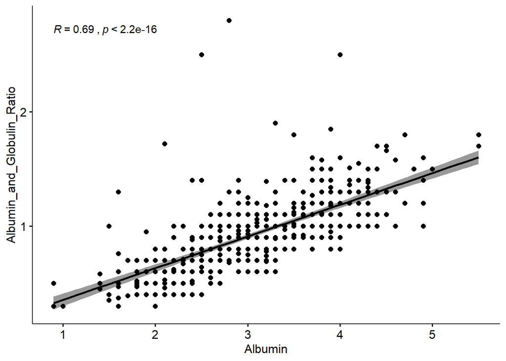

```r
ggscatter(data = liver_data, x = "Albumin", y = "Albumin_and_Globulin_Ratio",
          add = "reg.line", conf.int = TRUE,
          cor.coef = TRUE, cor.method = "pearson",

          xlab = "Albumin", ylab = "Albumin_and_Globulin_Ratio")
```

These pairs are highly correlated and thus only 3 out of the 6 features need to be selected as they would have the same impact on the model. Eliminating Gender, Direct_Bilrubin, Alkaline_Phosphotase, Asparate_Amino_Transferase, in an attempt to build more robust models.

```r
#Select the columns we need as predictors
str(liver_data)
```

```
## Classes 'tbl_df', 'tbl' and 'data.frame':    579 obs. of  11 variables:
##  $ Age                       : num  65 62 62 58 72 46 26 29 17 55 ...
##  $ Gender                    : chr  "Female" "Male" "Male" "Male" ...
##  $ Total_Bilirubin           : num  0.7 10.9 7.3 1 3.9 1.8 0.9 0.9 0.9 0.7 ...
##  $ Direct_Bilirubin          : num  0.1 5.5 4.1 0.4 2 0.7 0.2 0.3 0.3 0.2 ...
##  $ Alkaline_Phosphotase      : num  187 699 490 182 195 208 154 202 202 290 ...
##  $ Alamine_Aminotransferase  : num  16 64 60 14 27 19 16 14 22 53 ...
##  $ Aspartate_Aminotransferase: num  18 100 68 20 59 14 12 11 19 58 ...
##  $ Total_Protiens            : num  6.8 7.5 7 6.8 7.3 7.6 7 6.7 7.4 6.8 ...
##  $ Albumin                   : num  3.3 3.2 3.3 3.4 2.4 4.4 3.5 3.6 4.1 3.4 ...
##  $ Albumin_and_Globulin_Ratio: num  0.9 0.74 0.89 1 0.4 1.3 1 1.1 1.2 1 ...
##  $ Dataset                   : num  1 1 1 1 1 1 1 1 0 1 ...
```

```r
liver_data <- liver_data[,c(1,3,6,8,9,10,11)]
colnames(liver_data)
```

```
## [1] "Age"                        "Total_Bilirubin"
## [3] "Alamine_Aminotransferase"   "Total_Protiens"
## [5] "Albumin"                    "Albumin_and_Globulin_Ratio"
## [7] "Dataset"
```

```r
# 70% of the sample size
smp_size <- floor(0.70 * nrow(liver_data))

## set the seed to make your partition reproducible
set.seed(123)
train_ind <- sample(seq_len(nrow(liver_data)), size = smp_size)
train_data <- liver_data[train_ind, ]
test_data <- liver_data[-train_ind, ]

str(train_data)
```

```
## Classes 'tbl_df', 'tbl' and 'data.frame':    405 obs. of  7 variables:
##  $ Age                       : num  55 65 22 56 54 34 54 49 38 38 ...
##  $ Total_Bilirubin           : num  75 1.1 0.8 1 5.5 4.1 1.4 1 3.7 0.8 ...
##  $ Alamine_Aminotransferase  : num  40 16 57 22 67 875 36 48 179 25 ...
##  $ Total_Protiens            : num  6.2 5.7 7.9 5.8 7 5 7.9 8.4 7.8 7 ...
##  $ Albumin                   : num  2.5 1.5 3.8 2.6 3.2 2.7 3.7 4.2 4.5 3 ...
##  $ Albumin_and_Globulin_Ratio: num  0.6 0.35 0.9 0.8 0.8 1.1 0.9 1 1.3 0.7 ...
##  $ Dataset                   : num  1 1 0 0 1 1 0 1 1 1 ...
```

```r
str(test_data)
```

```
## Classes 'tbl_df', 'tbl' and 'data.frame':    174 obs. of  7 variables:
##  $ Age                       : num  46 29 55 57 72 64 38 34 57 57 ...
##  $ Total_Bilirubin           : num  1.8 0.9 0.7 0.6 2.7 0.9 1.8 4.1 4 1 ...
##  $ Alamine_Aminotransferase  : num  19 14 53 51 31 61 168 875 45 19 ...
##  $ Total_Protiens            : num  7.6 6.7 6.8 5.9 7.4 7 7.6 5 5.2 5.2 ...
##  $ Albumin                   : num  4.4 3.6 3.4 2.7 3 3.4 4.4 2.7 1.5 2.9 ...
##  $ Albumin_and_Globulin_Ratio: num  1.3 1.1 1 0.8 0.6 0.9 1.3 1.1 0.4 1.2 ...
##  $ Dataset                   : num  1 1 1 1 1 0 1 1 1 0 ...
```

```r
str(liver_data)
```

```
## Classes 'tbl_df', 'tbl' and 'data.frame':    579 obs. of  7 variables:
##  $ Age                       : num  65 62 62 58 72 46 26 29 17 55 ...
##  $ Total_Bilirubin           : num  0.7 10.9 7.3 1 3.9 1.8 0.9 0.9 0.9 0.7 ...
##  $ Alamine_Aminotransferase  : num  16 64 60 14 27 19 16 14 22 53 ...
##  $ Total_Protiens            : num  6.8 7.5 7 6.8 7.3 7.6 7 6.7 7.4 6.8 ...
##  $ Albumin                   : num  3.3 3.2 3.3 3.4 2.4 4.4 3.5 3.6 4.1 3.4 ...
##  $ Albumin_and_Globulin_Ratio: num  0.9 0.74 0.89 1 0.4 1.3 1 1.1 1.2 1 ...
##  $ Dataset                   : num  1 1 1 1 1 1 1 1 0 1 ...
```

Now that the data has been prepared, the model construction process can be initiated. Since this is a classificaiton problem, the implementation of KNN, CART, and Logistic Regression.

Building the KNN model:

```r
############################################################################################
### K - Nearest Neighbours
############################################################################################

train_knn <- train_data
test_knn <- test_data
str(train_knn)
```

```
## Classes 'tbl_df', 'tbl' and 'data.frame':    405 obs. of  7 variables:
##  $ Age                       : num  55 65 22 56 54 34 54 49 38 38 ...
##  $ Total_Bilirubin           : num  75 1.1 0.8 1 5.5 4.1 1.4 1 3.7 0.8 ...
##  $ Alamine_Aminotransferase  : num  40 16 57 22 67 875 36 48 179 25 ...
##  $ Total_Protiens            : num  6.2 5.7 7.9 5.8 7 5 7.9 8.4 7.8 7 ...
##  $ Albumin                   : num  2.5 1.5 3.8 2.6 3.2 2.7 3.7 4.2 4.5 3 ...
##  $ Albumin_and_Globulin_Ratio: num  0.6 0.35 0.9 0.8 0.8 1.1 0.9 1 1.3 0.7 ...
##  $ Dataset                   : num  1 1 0 0 1 1 0 1 1 1 ...
```

```r
str(test_knn)
```

```
## Classes 'tbl_df', 'tbl' and 'data.frame':    174 obs. of  7 variables:
##  $ Age                       : num  46 29 55 57 72 64 38 34 57 57 ...
##  $ Total_Bilirubin           : num  1.8 0.9 0.7 0.6 2.7 0.9 1.8 4.1 4 1 ...
##  $ Alamine_Aminotransferase  : num  19 14 53 51 31 61 168 875 45 19 ...
##  $ Total_Protiens            : num  7.6 6.7 6.8 5.9 7.4 7 7.6 5 5.2 5.2 ...
##  $ Albumin                   : num  4.4 3.6 3.4 2.7 3 3.4 4.4 2.7 1.5 2.9 ...
##  $ Albumin_and_Globulin_Ratio: num  1.3 1.1 1 0.8 0.6 0.9 1.3 1.1 0.4 1.2 ...
##  $ Dataset                   : num  1 1 1 1 1 0 1 1 1 0 ...
```

```r
#Our target variable is 'Dataset' variable
#To remove target variable from training and testing data
train_knn2 <- train_knn[, -7]
train_knn2 <- scale(train_knn2)
test_knn2 <- test_knn[ ,-7]
test_knn2 <- scale(test_knn2)
#To check if traget variable has been removed
str(train_knn2)
```

```
##  num [1:405, 1:6] 0.571 1.188 -1.465 0.633 0.509 ...
##  - attr(*, "dimnames")=List of 2
##   ..$ : NULL
##   ..$ : chr [1:6] "Age" "Total_Bilirubin" "Alamine_Aminotransferase" "Total_Protiens" ...
##  - attr(*, "scaled:center")= Named num [1:6] 45.74 3.15 81.51 6.42 3.09 ...
##   ..- attr(*, "names")= chr [1:6] "Age" "Total_Bilirubin" "Alamine_Aminotransferase" "Total_Protiens" ...
##  - attr(*, "scaled:scale")= Named num [1:6] 16.21 6.17 189.78 1.12 0.81 ...
##   ..- attr(*, "names")= chr [1:6] "Age" "Total_Bilirubin" "Alamine_Aminotransferase" "Total_Protiens" ...
```

```r
str(test_knn2)
```

```
##  num [1:174, 1:6] 0.215 -0.842 0.774 0.899 1.832 ...
##  - attr(*, "dimnames")=List of 2
##   ..$ : NULL
##   ..$ : chr [1:6] "Age" "Total_Bilirubin" "Alamine_Aminotransferase" "Total_Protiens" ...
##  - attr(*, "scaled:center")= Named num [1:6] 42.55 3.69 80.23 6.61 3.26 ...
##   ..- attr(*, "names")= chr [1:6] "Age" "Total_Bilirubin" "Alamine_Aminotransferase" "Total_Protiens" ...
##  - attr(*, "scaled:scale")= Named num [1:6] 16.081 6.351 167.343 0.988 0.746 ...
##   ..- attr(*, "names")= chr [1:6] "Age" "Total_Bilirubin" "Alamine_Aminotransferase" "Total_Protiens" ...
```

```r
train_knn_label <- train_knn$Dataset
test_knn_label <- test_knn$Dataset
str(train_knn_label)
```

```
##  num [1:405] 1 1 0 0 1 1 0 1 1 1 ...
```

```r
str(test_knn_label)
```

```
##  num [1:174] 1 1 1 1 1 0 1 1 1 0 ...
```

# Building a KNN model

```r
library(class)
library(pROC)
```

```r
pred_knn <- knn(train = train_knn2, test = test_knn2, cl = train_knn_label, k = 1)
table_knn <- table(test_knn_label, pred_knn)
total <- table_knn[1,1] + table_knn[2,2]
accuracy <- (total/174)*100
accuracy
```

```
## [1] 66.09195
```

```r
#Choosing best value of K
k1 <- knn(train = train_knn2, test = test_knn2, cl = train_knn_label, k=1)
table1 <- table(k1, test_knn_label)
TotalCorrect1 <- table1[1,1] + table1[2,2]
Accuracy1 <- (TotalCorrect1/174)*100
print(Accuracy1)
```

```
## [1] 66.09195
```

```r
k3 <- knn(train = train_knn2, test = test_knn2, cl = train_knn_label, k=3)
table3 <- table(k3, test_knn_label)
TotalCorrect3 <- table3[1,1] + table3[2,2]
Accuracy3 <- (TotalCorrect3/174)*100
print(Accuracy3)
```

```
## [1] 68.3908
```

```r
k5 <- knn(train = train_knn2, test = test_knn2, cl = train_knn_label, k=5)
table5 <- table(k5, test_knn_label)
TotalCorrect5 <- table5[1,1] + table5[2,2]
Accuracy5 <- (TotalCorrect5/174)*100
print(Accuracy5)
```

```
## [1] 69.54023
```

```r
k7 <- knn(train = train_knn2, test = test_knn2, cl = train_knn_label, k=7)
table7 <- table(k7, test_knn_label)
TotalCorrect7 <- table7[1,1] + table7[2,2]
Accuracy7 <- (TotalCorrect7/174)*100
print(Accuracy7)
```

```
## [1] 68.96552
```

```r
k9 <- knn(train = train_knn2, test = test_knn2, cl = train_knn_label, k=9)
table9 <- table(k9, test_knn_label)
TotalCorrect9 <- table9[1,1] + table9[2,2]
Accuracy9 <- (TotalCorrect9/174)*100
print(Accuracy9)
```

```
## [1] 74.13793
```

```r
k11 <- knn(train = train_knn2, test = test_knn2, cl = train_knn_label, k=11)
table11 <- table(k11, test_knn_label)
TotalCorrect11 <- table11[1,1] + table11[2,2]
Accuracy11 <- (TotalCorrect11/174)*100
print(Accuracy11)
```

```
## [1] 75.28736
```

```r
k13 <- knn(train = train_knn2, test = test_knn2, cl = train_knn_label, k=13)
table13 <- table(k13, test_knn_label)
TotalCorrect13 <- table13[1,1] + table13[2,2]
Accuracy13 <- (TotalCorrect13/174)*100
print(Accuracy13)
```

```
## [1] 71.83908
```

```r
k15 <- knn(train = train_knn2, test = test_knn2, cl = train_knn_label, k=15)
table15 <- table(k15, test_knn_label)
TotalCorrect15 <- table15[1,1] + table15[2,2]
Accuracy15 <- (TotalCorrect15/174)*100
print(Accuracy15)
```

```
## [1] 71.26437
```

```r
k17 <- knn(train = train_knn2, test = test_knn2, cl = train_knn_label, k=17)
table17 <- table(k17, test_knn_label)
TotalCorrect17 <- table17[1,1] + table17[2,2]
Accuracy17 <- (TotalCorrect17/174)*100
print(Accuracy17)
```

```
## [1] 74.71264
```

```r
k19 <- knn(train = train_knn2, test = test_knn2, cl = train_knn_label, k=19)
table19 <- table(k19, test_knn_label)
TotalCorrect19 <- table19[1,1] + table19[2,2]
Accuracy19 <- (TotalCorrect19/174)*100
print(Accuracy19)
```

```
## [1] 71.83908
```

```r
k21 <- knn(train = train_knn2, test = test_knn2, cl = train_knn_label, k=21)
table21 <- table(k21, test_knn_label)
TotalCorrect21 <- table21[1,1] + table21[2,2]
Accuracy21 <- (TotalCorrect21/174)*100
print(Accuracy21)
```

```
## [1] 70.11494
```

```r
k23 <- knn(train = train_knn2, test = test_knn2, cl = train_knn_label, k=23)
table23 <- table(k23, test_knn_label)
TotalCorrect23 <- table23[1,1] + table23[2,2]
Accuracy23 <- (TotalCorrect23/174)*100
print(Accuracy23)
```

```
## [1] 74.71264
```

```r
k25 <- knn(train = train_knn2, test = test_knn2, cl = train_knn_label, k=25)
table25 <- table(k25, test_knn_label)
table25
```

```
##    test_knn_label
## k25   0   1
##   0  11  13
##   1  28 122
```

```r
TotalCorrect25 <- table25[1,1] + table25[2,2]
Accuracy25 <- (TotalCorrect25/174)*100
print(Accuracy25)
```

```
## [1] 76.43678
```

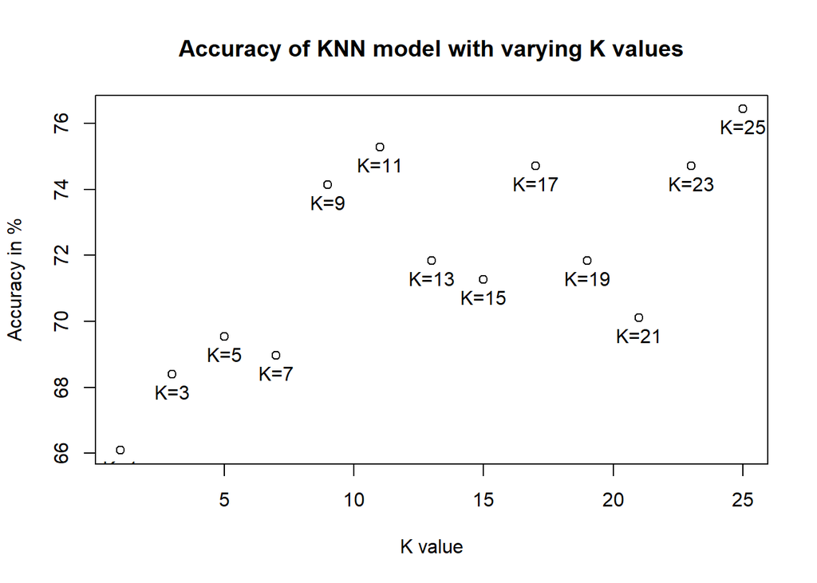

```r
#Ploting K values and Accuracy
plot_accuracy <- c(Accuracy1, Accuracy3, Accuracy5, Accuracy7, Accuracy9,
                   Accuracy11, Accuracy13, Accuracy15, Accuracy17, Accuracy19,
                   Accuracy21,Accuracy23,Accuracy25)
plot_Klabels <- c("K=1","K=3","K=5","K=7","K=9",
                  "K=11","K=13","K=15","K=17","K=19",
                  "K=21","K=23","K=25")
K_values <- c(1,3,5,7,9,11,13,15,17,19,21,23,25)
plot(x=K_values,y=plot_accuracy,xlab ="K value", ylab = "Accuracy in %",
     main="Accuracy of KNN model with varying K values")
text(x=K_values,y=plot_accuracy,labels=plot_Klabels, pos =1 )
```

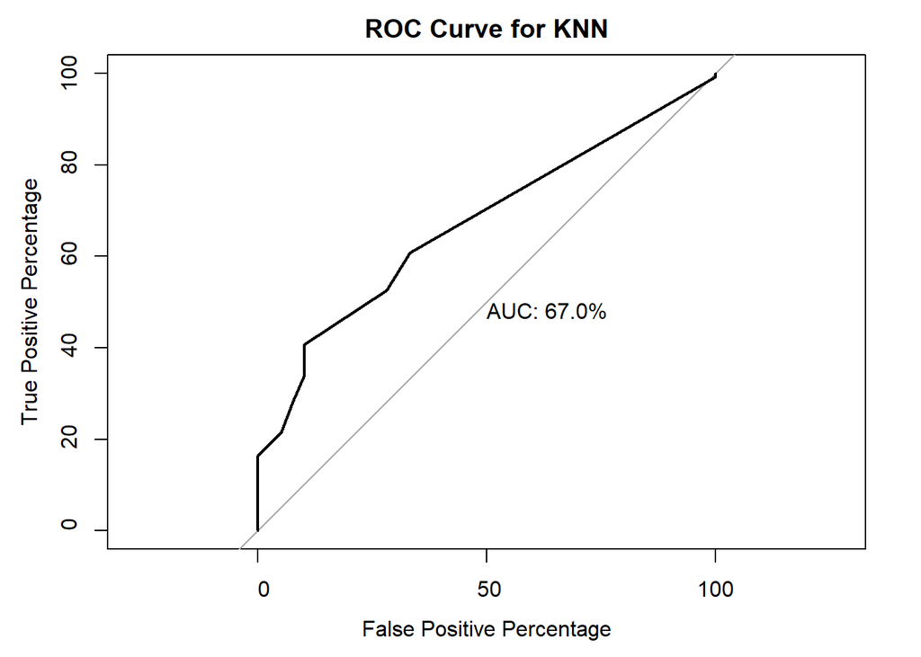

```
##
## Call:
## roc.default(response = test_knn_label, predictor = k25_prob,     percent = TRUE, plot = TRUE, legacy.axes = TRUE, main = "ROC Curve for KNN",     xlab = "False Positive Percentage", ylab = "True Positive Percentage",     print.auc = TRUE)
##
## Data: k25_prob in 39 controls (test_knn_label 0) < 135 cases (test_knn_label 1).
## Area under the curve: 67.02%
```

```r
#Metrics for best K value

error_rate <- (table25[1,2] +  table25[2,1]) / 174


false_pos_rate <- table25[2,1]/(table25[2,1] + table25[2,2])

#ROC Curve
k25 <- knn(train = train_knn2, test = test_knn2, cl = train_knn_label, k=25, prob = TRUE)
k25_prob<-attr(k25, "prob")
roc(test_knn_label,k25_prob, plot=TRUE,legacy.axes = TRUE, percent = TRUE, main = "ROC Curve for KNN" ,xlab="False Positive Percentage", ylab ="True Positive Percentage", print.auc = TRUE)
```

The error rate is 0.2356322.

The false positive rate is 0.1866667.

Running a Logistic Regression Model:

```r
#Libraries:
library(car)
library(caret)
library(lattice)
library(party)
```

```r
#Logistic regression Model:
#Creating a "0-1" column:
patients<-liver_data
colnames(patients)
```

```
## [1] "Age"                        "Total_Bilirubin"
## [3] "Alamine_Aminotransferase"   "Total_Protiens"
## [5] "Albumin"                    "Albumin_and_Globulin_Ratio"
## [7] "Dataset"
```

```r
#Creating the regression model:
logmod<- glm(Dataset~.,data = patients,family = binomial())
#Predicting the values:
pred<-predict(logmod, type = "response")
#Creating a confusion matrix to evaluate the results:
confusionMatrix(as.factor(patients$Dataset),as.factor(ifelse(pred>0.5,1,0)))
```

```
## Confusion Matrix and Statistics
##
##           Reference
## Prediction   0   1
##          0  40 125
##          1  28 386
##
##                Accuracy : 0.7358
##                  95% CI : (0.6978, 0.7712)
##     No Information Rate : 0.8826
##     P-Value [Acc > NIR] : 1
##
##                   Kappa : 0.2123
##  Mcnemar's Test P-Value : 8.417e-15
##
##             Sensitivity : 0.58824
##             Specificity : 0.75538
##          Pos Pred Value : 0.24242
##          Neg Pred Value : 0.93237
##              Prevalence : 0.11744
##          Detection Rate : 0.06908
##    Detection Prevalence : 0.28497
##       Balanced Accuracy : 0.67181
##
##        'Positive' Class : 0
##
```

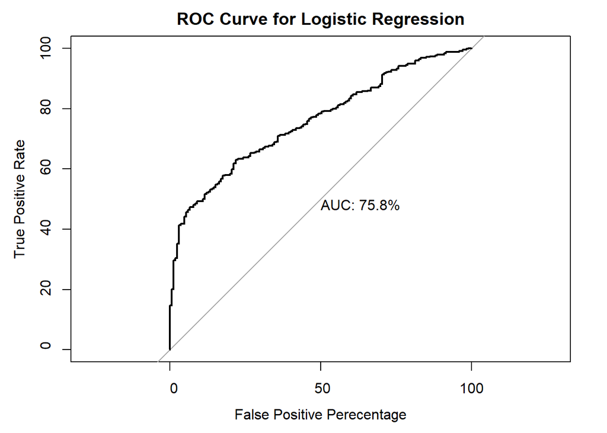

```
##
## Call:
## roc.default(response = patients$Dataset, predictor = pred, percent = TRUE,     plot = TRUE, legacy.axes = TRUE, main = "ROC Curve for Logistic Regression",     xlab = "False Positive Perecentage", ylab = "True Positive Rate",     print.auc = TRUE)
##
## Data: pred in 165 controls (patients$Dataset 0) < 414 cases (patients$Dataset 1).
## Area under the curve: 75.76%
```

```r
#Plotting the ROC Curve:
roc(patients$Dataset,pred, plot=TRUE, percent = TRUE, legacy.axes=TRUE, main="ROC Curve for Logistic Regression" ,xlab = "False Positive Perecentage", ylab="True Positive Rate", print.auc=TRUE)
```

Implementing a CART model on the dataset:

```r
#Decision Tress:
#library
library(rpart)
library(rpart.plot)
library(maptree)
library(cluster)
```

```r
#Creating the model
dtmodel<-rpart(Dataset~.,data = patients, method = "class")
printcp(dtmodel)
```

```
##
## Classification tree:
## rpart(formula = Dataset ~ ., data = patients, method = "class")
##
## Variables actually used in tree construction:
## [1] Age                        Alamine_Aminotransferase
## [3] Albumin                    Albumin_and_Globulin_Ratio
## [5] Total_Bilirubin            Total_Protiens
##
## Root node error: 165/579 = 0.28497
##
## n= 579
##
##         CP nsplit rel error xerror     xstd
## 1 0.024242      0   1.00000 1.0000 0.065829
## 2 0.018182      4   0.89697 1.0424 0.066640
## 3 0.012121     10   0.77576 1.0667 0.067079
## 4 0.010000     19   0.66667 1.1212 0.068000
```

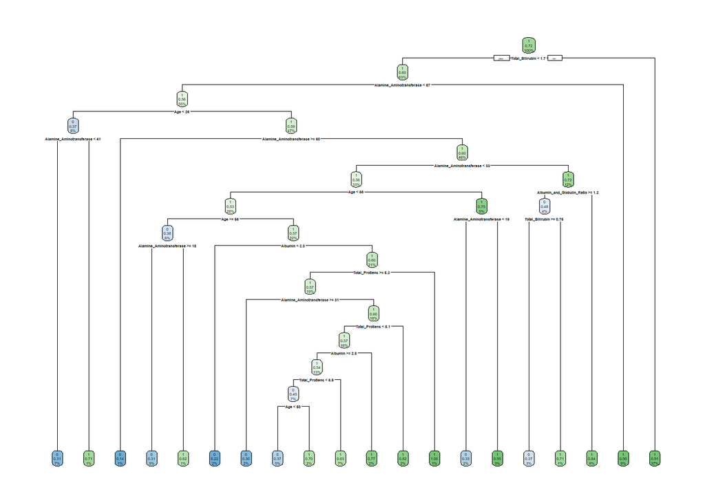

```r
rpart.plot(dtmodel)
```

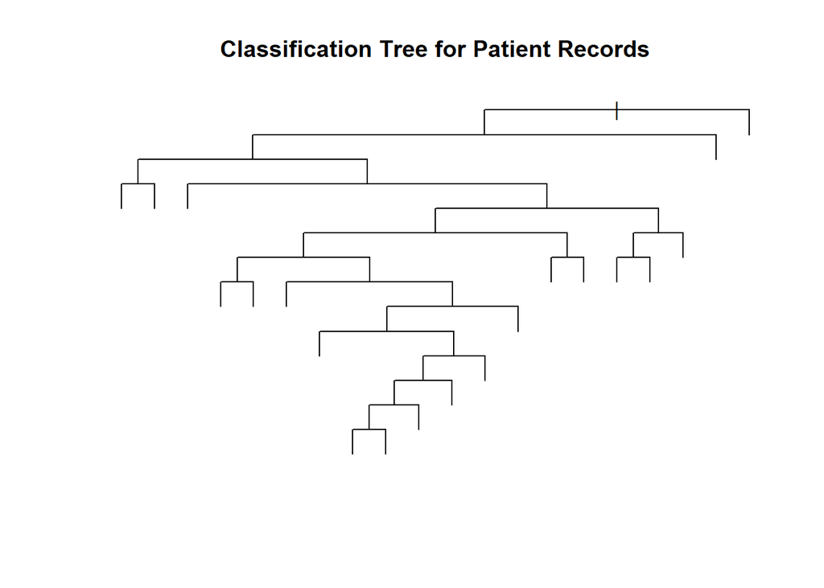

```r
#Decision Tree Plot
plot(dtmodel, uniform=TRUE, main="Classification Tree for Patient Records")
```

```r
#Testing the model:
dtpred<-predict(dtmodel,type = "class")

#Confusion Matrix:
confusionMatrix(dtpred,as.factor(patients$Dataset))
```

```
## Confusion Matrix and Statistics
##
##           Reference
## Prediction   0   1
##          0 102  47
##          1  63 367
##
##                Accuracy : 0.81
##                  95% CI : (0.7756, 0.8412)
##     No Information Rate : 0.715
##     P-Value [Acc > NIR] : 9.205e-08
##
##                   Kappa : 0.5198
##  Mcnemar's Test P-Value : 0.1527
##
##             Sensitivity : 0.6182
##             Specificity : 0.8865
##          Pos Pred Value : 0.6846
##          Neg Pred Value : 0.8535
##              Prevalence : 0.2850
##          Detection Rate : 0.1762
##    Detection Prevalence : 0.2573
##       Balanced Accuracy : 0.7523
##
##        'Positive' Class : 0
##
```

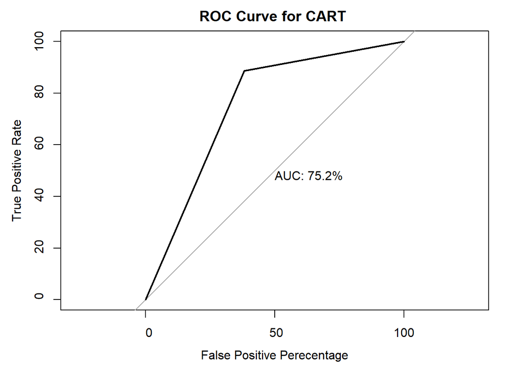

```
##
## Call:
## roc.default(response = patients$Dataset, predictor = as.numeric(dtpred),     percent = TRUE, plot = TRUE, legacy.axes = TRUE, main = "ROC Curve for CART ",     xlab = "False Positive Perecentage", ylab = "True Positive Rate",     print.auc = TRUE)
##
## Data: as.numeric(dtpred) in 165 controls (patients$Dataset 0) < 414 cases (patients$Dataset 1).
## Area under the curve: 75.23%
```

```r
#ROC Plot
roc(patients$Dataset,as.numeric(dtpred), plot=TRUE, percent = TRUE, legacy.axes=TRUE, main="ROC Curve for CART ",xlab = "False Positive Perecentage", ylab="True Positive Rate", print.auc=TRUE)
```

From the three fitted models, it is evident that the best model is the logistic regression model, since it has the highest AUC of 75.8%. Based on this an appropriate cut-off can be selected using data extracted from the ROC curve, making a trade off between the Falase Positive Rate and the True Positive Rate. In this case study, the goal should be to reduce the number of false negative cases, even though this may decrease the accuracy of the model. This is because, missing out on a patient’s disease, could prove fatal for the patient, and is much worse than incorrectly predicting the presence of a liver disease.

### Conclusion and Scope:

This is a promosing project, that could be worked on further to create better models and eventually be good enough to implement in the the real world, saving doctors’ precious time around the globe, and help save lives. As we were pressed on time while working on this project, we did not fine tune our models. If given more time, we could have put in more effort on feature selection, and model tuning, which would have resulted in better results. The data set consisted of mainly male patients and was too small to better train the models.For future work, more data needs to be collected to get a more rounded dataset and use better machine learning algorithms to tackle this problem.